# 170427_HW10_DimReduct

Kuei Yueh Ko

2017年5月4日

# Set Environment

import needed package

```r
library(ComplexHeatmap)
library(knitr)
```

set directories

```r
workdir <- "C:\\Users\\clint\\Documents\\GitHub\\BlogDataAnalysis"
setwd(workdir)

filePathData <- file.path(
    workdir,
    "Data/StatCompEcology/Copepod")
```

# Import data

Read in the copepod data recorded in different stations and preprocess the data to find the dominant species. The final matrix is teh frequency matrix of dominant species in different stations

1. cop_density.txt
   - copepod total density (number/m^3) recorded in each station
2. copepod_composition.txt
   - frequency of each copepod specie recorded in each station.
3. copepodSPlist.txt
   - Species names along the rows of data copepod_composition.txt

**Note: Definition of dominant species:**

- species >=2% of total composition in any cruise-station

```r
# intialize a list to store data
datCPOD <- list()

# read tables: number of copepod in each station
# 34 stations
dat <- read.table(file.path(
    filePathData, "cop_density.txt"),
    header=T)
datCPOD$Density <- dat

# read tables: freq of copepod in each station
# 34 stations x 181 species
dat <- read.table(file.path(
    filePathData, "copepod_composition.txt"),
    header=T)
datCPOD$Compose <- dat

# read tables: species name
# 181 species
dat <- read.table(file.path(
    filePathData, "copepodSPlist.txt"),
    sep="\t", header=F)
datCPOD$SP_Total <- as.character(dat$V1)

# Search for dominant species
dat <- datCPOD$Compose
temp <- apply(dat >= 2, 1, sum)
datCPOD$SP_Dominant <- which(temp > 0)

# Extract the composition of dominant species
dat <- datCPOD$Compose
idx <- datCPOD$SP_Dominant
idn <- datCPOD$SP_Total
dat <- dat[idx,]
rownames(dat) <- idn[idx]

# composition of dominant species
# Note: transform the matrix since
# we are clustering on stations
datCPOD$CompDmt <- t(dat)
datCPOD$CompDmtScale <- scale(t(dat)) # scales the columns of a numeric matrix
#head(datCPOD$CompDmtScale)
```

Visualize the data after preprocess (find the dominant species and scale the result data matrix)

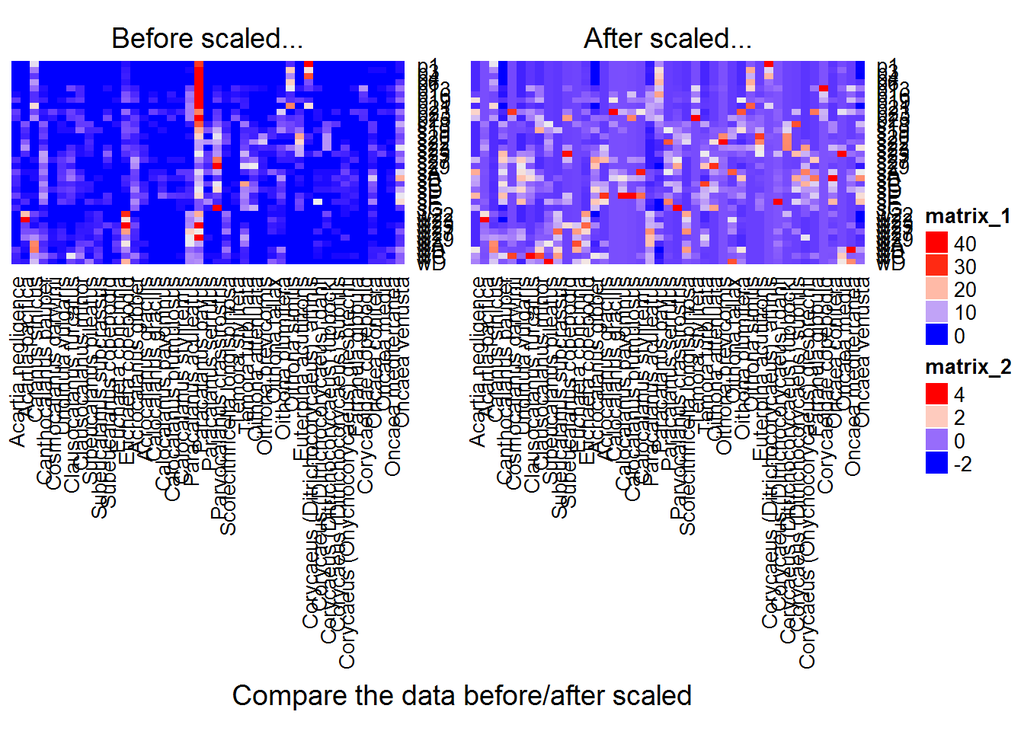

```r
# Original data matrix of dominant species in different stations
dat <- datCPOD$CompDmt
ht1 <- Heatmap(
    dat, column_title = "Before scaled...",
    row_names_gp = gpar(fontsize = 10),
    column_names_max_height=unit(15, "cm"),
    column_names_gp = gpar(fontsize = 10),
    cluster_rows=F, cluster_columns=F)

# Scaled data matrix of dominant species in different stations
dat <- datCPOD$CompDmtScale
ht2 <- Heatmap(
    dat, column_title = "After scaled...",
    row_names_gp = gpar(fontsize = 10),
    column_names_max_height=unit(15, "cm"),
    column_names_gp = gpar(fontsize = 10),
    cluster_rows=F, cluster_columns=F)

# plot
draw(ht1 + ht2,
     column_title = "Compare the data before/after scaled",
     column_title_side = "bottom")
```

# Principal Component Analysis (Using Linear Algebra)

## Eigendecomposition (Diagnolization)

Suppose we have a data matrix with n observations and p variables

$X \in \mathbb{R}^{nxp}$

We can calculate the correlation matrix of variables, resulting in a pxp matrix

$\Sigma = \frac{1}{n-1} X^T H X$

Perform eigendecomposition

$\Sigma = Q \Lambda Q^T$

$Q = [v_1 v_2 \cdots v_p] D = [\lambda_1 \lambda_2 \cdots \lambda_p]$

where

$\Sigma v_i = \lambda_i v_i$

$\Sigma = \lambda_1 v_1 v_1^T + \cdots + \lambda_p v_p v_p^T$

```r
dat <- datCPOD$CompDmtScale
mat <- cor(dat)
res.eig <- eigen(mat)
#res.pca <- prcomp(dat, scale=TRUE, center=TRUE)
```

## Eigenvalues and Variance

```r
# Eigenvalues
eig <- res.eig$values^0.5
eig <- eig[!is.na(eig)]

# Variances in percentage
variance <- eig*100/sum(eig)

# Cumulative variances
cumvar <- cumsum(variance)

# Combine the result
dat <- data.frame(
    eig = eig,
    variance = variance,
    cumvariance = cumvar)
kable(head(dat))
```

| eig | variance | cumvariance |
| --- | --- | --- |
| 2.879412 | 9.403776 | 9.403776 |
| 2.306201 | 7.531745 | 16.935520 |
| 2.113617 | 6.902790 | 23.838311 |
| 1.707129 | 5.575257 | 29.413568 |
| 1.544074 | 5.042740 | 34.456308 |
| 1.540962 | 5.032576 | 39.488883 |

## The screeplot of variance (Eigen value)

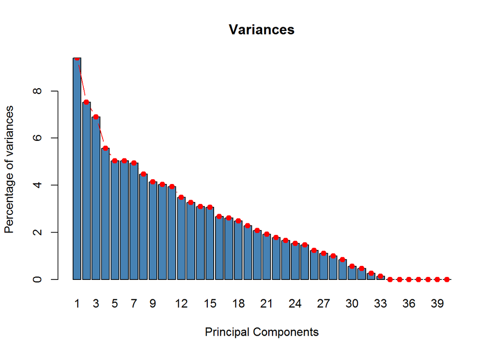

```r
# Barplot of the value of variance in percentage
plt <- barplot(
    dat$variance,
    names.arg=1:nrow(dat),
    main = "Variances",
    xlab = "Principal Components",
    ylab = "Percentage of variances",
    col ="steelblue")

# Add connected line segments to the plot
lines(x = plt,
      y = dat$variance,
      type="b", pch=19, col = "red")
```

## PCA Scores

The effect of diagnolization is to change the data into the new basis, which is the eigenvectors. Let new coordinates $Y=XQ$

```r
dat <- datCPOD$CompDmtScale
mat <- res.eig$vectors
res.eig$x <- as.matrix(dat) %*% mat
```

## PCA Loading

The meaning of PCA loading is the correlation between the PC scores and the variables in original data matrix. That is, loadings are the correlation of variables before change of basis and after change of basis.

In fact, the following two equations allow us to calculate PCA loadings

$[\sqrt{\lambda_1} v_1 \cdots \sqrt{\lambda_p} v_p] = QD^\frac{1}{2}$

$\frac{1}{n-1} X^T H scaled(Y)$

```r
# Here we will try four kinds of calculation
dat <- datCPOD$CompDmtScale
vec <- res.eig$values^0.5
mat <- res.eig$vectors
res <- list()
```

Calculate the loading by

$[\sqrt{\lambda_1} v_1 \cdots \sqrt{\lambda_p} v_p] = QD^\frac{1}{2}$

```r
# Use apply
res$Method1 <- t(apply(mat, 1, function(x){x * vec}))

# Use Matrix Multiplication
res$Method2 <- mat %*% diag(vec)
```

Calculate the correlation of variables and PCA scores directly using loop

```r
# Calculate correlation
n <- ncol(dat)
idx <- expand.grid(1:n, 1:n)

tmp  <- mapply(
    function(idx1,idx2){
        cor(dat[,idx1], res.eig$x[,idx2])
    },idx[,1], idx[,2])

res$Method3 <- matrix(tmp,n,n,byrow = FALSE)
```

Calculate the correlation of matrix of X and Y. Since the X matrix is scaled already, here we will scaled Y before calculation.

$\Sigma = \frac{1}{n-1} X^T H scaled(Y)$

```r
n <- nrow(dat)
H <- diag(n) - 1/n * outer(rep(1,n), rep(1,n))
res$Method4 = 1/(n-1) * t(as.matrix(dat)) %*% H %*% scale(res.eig$x)
```

It turns out all the calculations result in the same results

```r
res$Method1[1:5, 1:5]
```

```
##            [,1]         [,2]        [,3]        [,4]        [,5]
## [1,]  0.5758652  0.492714302  0.21930953 -0.12927408 -0.31850098
## [2,] -0.2624119 -0.042779279 -0.28350052 -0.06680432 -0.24694895
## [3,] -0.5019363  0.430758340 -0.02983185  0.19316716  0.10639644
## [4,]  0.8020718  0.008623068 -0.25232001  0.23756597 -0.05814221
## [5,]  0.2081135  0.547637540  0.07371748 -0.07569628  0.09101690
```

```r
res$Method2[1:5, 1:5]
```

```
##            [,1]         [,2]        [,3]        [,4]        [,5]
## [1,]  0.5758652  0.492714302  0.21930953 -0.12927408 -0.31850098
## [2,] -0.2624119 -0.042779279 -0.28350052 -0.06680432 -0.24694895
## [3,] -0.5019363  0.430758340 -0.02983185  0.19316716  0.10639644
## [4,]  0.8020718  0.008623068 -0.25232001  0.23756597 -0.05814221
## [5,]  0.2081135  0.547637540  0.07371748 -0.07569628  0.09101690
```

```r
res$Method3[1:5, 1:5]
```

```
##            [,1]         [,2]        [,3]        [,4]        [,5]
## [1,]  0.5758652  0.492714302  0.21930953 -0.12927408 -0.31850098
## [2,] -0.2624119 -0.042779279 -0.28350052 -0.06680432 -0.24694895
## [3,] -0.5019363  0.430758340 -0.02983185  0.19316716  0.10639644
## [4,]  0.8020718  0.008623068 -0.25232001  0.23756597 -0.05814221
## [5,]  0.2081135  0.547637540  0.07371748 -0.07569628  0.09101690
```

```r
res$Method4[1:5, 1:5]
```

```
##                             [,1]         [,2]        [,3]        [,4]
## Acartia negligence     0.5758652  0.492714302  0.21930953 -0.12927408
## Acartia pacifica      -0.2624119 -0.042779279 -0.28350052 -0.06680432
## Calanus sinicus       -0.5019363  0.430758340 -0.02983185  0.19316716
## Canthocalanus pauper   0.8020718  0.008623068 -0.25232001  0.23756597
## Cosmocalanus darwinii  0.2081135  0.547637540  0.07371748 -0.07569628
##                              [,5]
## Acartia negligence    -0.31850098
## Acartia pacifica      -0.24694895
## Calanus sinicus        0.10639644
## Canthocalanus pauper  -0.05814221
## Cosmocalanus darwinii  0.09101690
```

```r
res.eig$loading <- res$Method1
res.eig$loading <- res$Method2
res.eig$loading <- res$Method3
res.eig$loading <- res$Method4
```

# Plotting

Graph of variables using R base graph

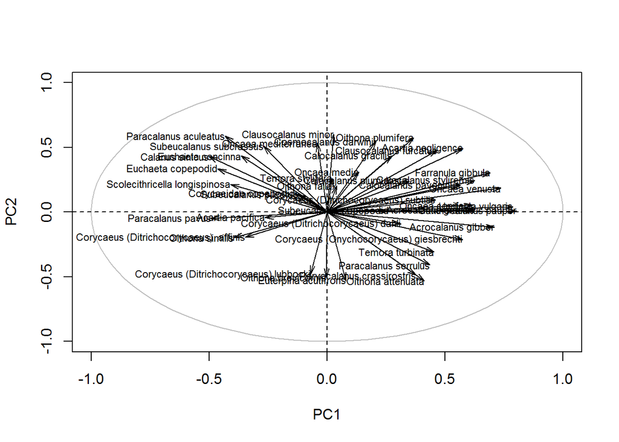

```r
# plot the loadings
mat <- res.eig$loading

# Plot the correlation circle
idx <- seq(0, 2*pi, length = 100)
plot(cos(idx), sin(idx),
     type = 'l', col="gray",
     xlab = "PC1", ylab = "PC2")
abline(h = 0, v = 0, lty = 2)

# Add active variables
arrows(0, 0, mat[, 1], mat[, 2],
      length = 0.1, angle = 15, code = 2)

# Add labels
text(mat, labels=rownames(mat), cex = 0.7, adj=1)
```

Graph of individuals : base graph

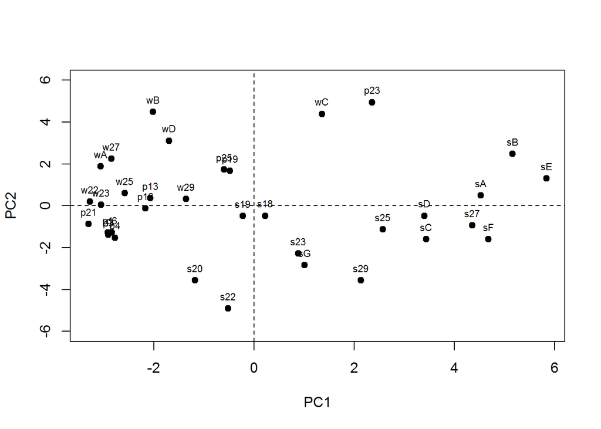

```r
# plot the scores
mat <- res.eig$x
plot(mat[,1], mat[,2],
     pch = 19,
     xlab="PC1",ylab="PC2",
     ylim=c(-6,6))

# add coordinates
abline(h=0, v=0, lty = 2)

# Add labels
text(mat[,1], mat[,2],
     labels=rownames(mat),
     cex=0.7, pos = 3)
```

plot in one figure

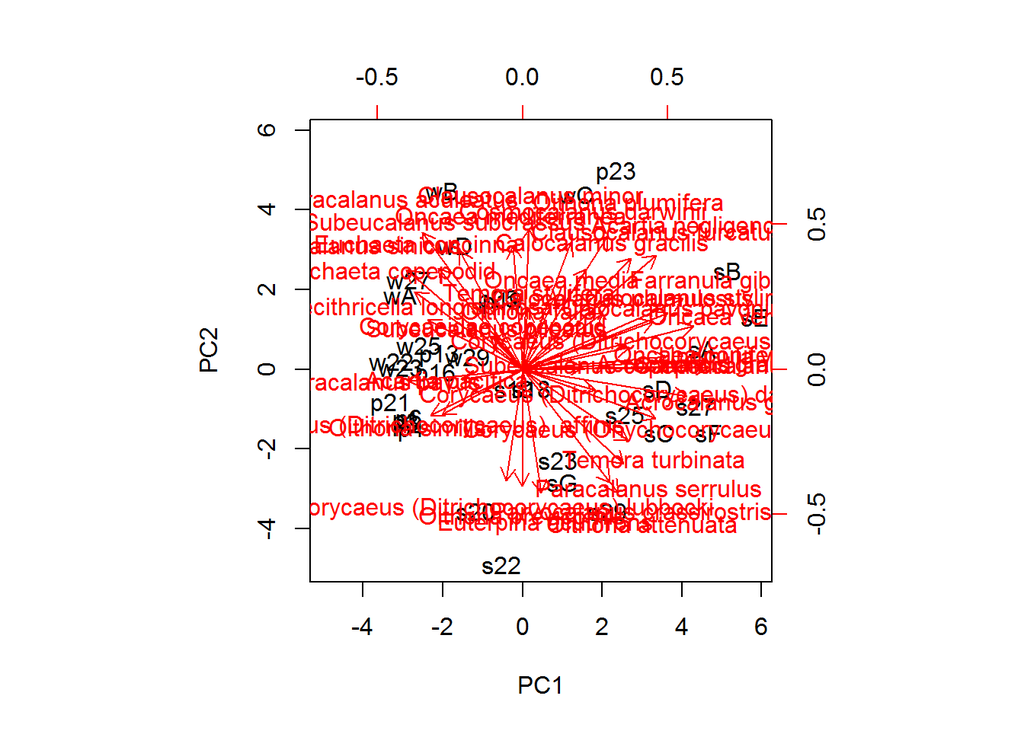

```r
biplot(res.eig$x, res.eig$loading,
       xlab = "PC1", ylab = "PC2")
```

# Multiple Dimensional Scaling (MDS)

Unlike PCA, which performs decomposition on covariance or correlation matrix, MDS performs decomposition on dissimilarity matrix, e.g. Euclidean distance.

The code refers to the website “R-statistics blog”

https://www.r-statistics.com/2016/01/multidimensional-scaling-with-r-from-mastering-data-analysis-with-r/

```r
dat <- datCPOD$CompDmtScale
mat <- as.matrix(dist(dat))
```

we can perform MDS analysis using the built-in function cmdscale

```r
res.mds <- cmdscale(mat, eig = TRUE, k = 2)
```

plot the results

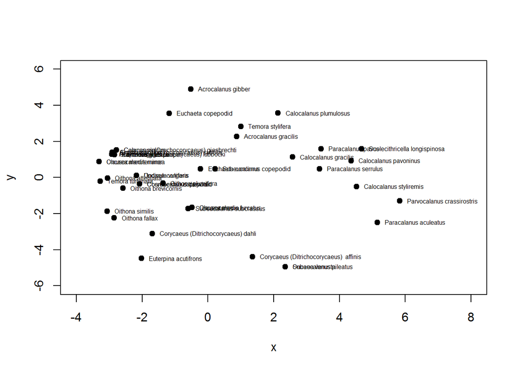

```r
# get the scores
x <- res.mds$points[, 1]
y <- res.mds$points[, 2]

# plot
plot(x, y, pch = 19,
     xlim = c(-4, 8),
     ylim = c(-6, 6))

# species names of dominant species
vec <- datCPOD$SP_Total[datCPOD$SP_Dominant]

# add labels
text(x, y, pos = 4, labels = vec, cex=0.5)
```

# Non metric MDS (NMDS)

The code refers to http://www.statmethods.net/advstats/mds.html

```r
dat <- datCPOD$CompDmtScale
mat <- as.matrix(dist(dat))
```

perform NMDS using function isoMDS

```r
# the function isoMDS if from library MASS
library(MASS)
# NDMS calculation
res.nmds <- isoMDS(mat)
```

plot the results

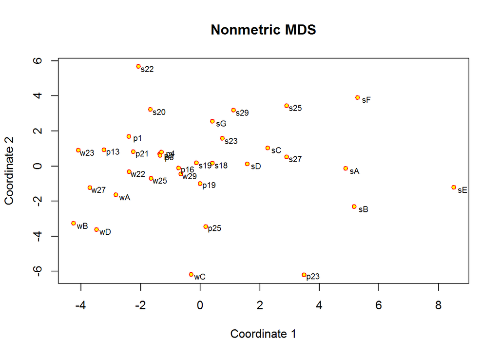

```r
# plot solution
x <- res.nmds$points[,1]
y <- res.nmds$points[,2]

# plot
plot(x, y,
     xlab="Coordinate 1",
     ylab="Coordinate 2",
     main="Nonmetric MDS", type="n")

# add points
points(x, y,
       cex = 0.8, pch=21,
       col="red", bg="yellow")

# add text
text(x+0.3, y-0.1, labels = row.names(dat), cex=.7)
```